# Culminating Activity

# Chapter 2: Review of Related Literature

## Conceptual Framework

At the core of this framework is the ultimate target variable: Job Satisfaction.

Rather than utilizing isolated linear regressions, the framework employs a Decision Tree architecture where predictor variables interact organically:

Primary Predictor: AI Tool Adoption is positioned as the central independent variable, hypothesized to simultaneously impact financial compensation and workflow friction.

Interacting Predictors: Financial Compensation (Salary) and Workflow Friction (Time Spent Searching) act as mediating variables within the model. Contextual Controls: Years of Experience and Remote Status serve as baseline variables to account for demographic and workplace variances.

The CART algorithm evaluates how these variables interact, specifically testing whether high compensation mathematically buffers the negative impact of AI-induced workflow friction when predicting final job satisfaction levels.

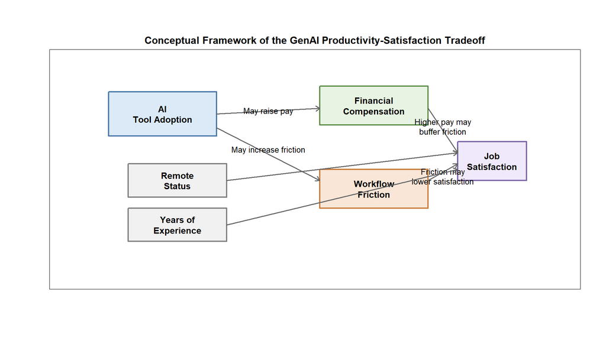

Conceptual Framework of the GenAI Productivity-Satisfaction Tradeoff

## Chapter 3: Methodology

Research Design

This study uses a quantitative, descriptive-correlational design to examine how AI adoption, salary, and workflow friction (as measured by Time Spent Searching & Debugging in minutes) relate to developer job satisfaction.

Data Collection The study uses secondary data from the Stack Overflow 2024 Developer Survey and limits the sample to respondents who identify as “Employed, full-time”.

Compensation and satisfaction responses are vulnerable to MNAR (Missing Not At Random) bias, so the analysis uses MICE with Classification and Regression Trees instead of listwise deletion.

The final modeling set was limited to Salary, Uses_AI, Years_Exp, Job_Satisfaction, Is_Remote, and TimeSearching because these variables align directly with compensation, AI adoption, seniority, work arrangement, and workflow friction.

Data Preparation and Initial Variable Selection

The raw survey file was reduced with filter_columns.r, which filtered for full-time employees and built the analysis table. Salary was derived from `ConvertedCompYearly`, Years_Exp from `YearsCodePro`, Uses_AI from `AISelect`, Job_Satisfaction from `JobSat`, and Is_Remote from `RemoteWork`. The output was saved to outputs/data_filtered_columns.csv.

These columns were kept because they capture the financial, behavioral, and contextual factors needed for the study question.

Initial Data Checks and EDA

The dataset was checked with check_data.r to review missingness patterns, unique-value counts, and basic distributions in both the raw survey data and the filtered modeling table.

Exploratory visualization was handled with eda.rmd to inspect the early relationships among AI adoption, salary, job satisfaction, experience, and time spent searching/debugging. This step served as a plausibility check before modeling.

Imputation and Modeling Workflow

The imputation step was handled in main.r, which creates or reuses outputs/data_imputed_primary.csv.

The baseline seed was updated to 200 after the seed-sensitivity check showed that it had the lowest xerror among the tested seeds.

Robustness Checks

The robustness work was separated into two parts. First, the hyperparameter shuffling held the imputed data fixed while varying model settings, which isolates model-choice effects. Second, the seed-sensitivity check changed the imputation seed while holding the CART settings fixed, which isolates data-uncertainty effects.

The seed-sensitivity workflow is documented in cart_robustness_check.r, and its outputs are saved to outputs/cart_mice_seed_runs.csv and outputs/cart_mice_seed_averages.csv. The CP profile is saved to outputs/cart_cp_profile.csv and provides an additional check on pruning.